# Spatiotemporal Burden of Endocrine, Nutritional and Metabolic Diseases (E00–E89) in Chile: A Nationwide Hospitalization Analysis, 2010–2024

Carga Espaciotemporal de las Enfermedades Endocrinas, Nutricionales y Metabólicas (E00–E89) en Chile: Análisis Nacional de Hospitalizaciones, 2010–2024

Authors

Dominga Elena Ramírez Reyes

María Matilde Vicuña Watkins

Antonia Fernanda Troncoso Páez

Josefina Poblete Moreno

Amaru Simón Agüero Jiménez

Published

March 31, 2026

**NoteResumen**

**EPIDEMIOLOGÍA DE HOSPITALIZACIONES POR ENFERMEDADES ENDOCRINAS Y METABÓLICAS EN CHILE: TENDENCIAS Y AUTOCORRELACIÓN ESPACIAL, 2010-2024**

**Introducción:** Las enfermedades endocrinas, nutricionales y metabólicas (CIE-10 E00-E89) representan una carga creciente para los sistemas de salud. En Chile, la diabetes mellitus alcanza el 12,3% y la obesidad el 34,4% en adultos.

**Materiales y Métodos:** Estudio descriptivo ecológico basado en Egresos Hospitalarios del DEIS, período 2010–2024. Se incluyeron egresos con diagnóstico principal E00-E89 clasificados en 10 categorías. Se calcularon tasas estandarizadas por edad (TEE) con la Población Estándar de la OMS. El análisis geoespacial comunal empleó Moran’s I y LISA con contigüidad Queen.

**Palabras clave:** enfermedades metabólicas; diabetes mellitus; obesidad; tasas estandarizadas por edad; análisis espacial.

**NoteAbstract**

**EPIDEMIOLOGY OF HOSPITALIZATIONS FOR ENDOCRINE AND METABOLIC DISEASES IN CHILE: TRENDS AND SPATIAL AUTOCORRELATION, 2010-2024**

**Introduction:** Endocrine, nutritional, and metabolic diseases (ICD-10 E00-E89) represent a growing burden on health systems. In Chile, diabetes mellitus prevalence reaches 12.3% and obesity 34.4% among adults.

**Materials and Methods:** Descriptive ecological study using the Hospital Discharge Database (EGRESOS) from DEIS, Chilean Ministry of Health, 2010–2024. Discharges with primary diagnosis E00–E89 were classified into 10 diagnostic categories. Age-standardized rates (ASR) were computed using the WHO World Standard Population. Municipal-level geospatial analysis employed Moran’s I and LISA with Queen contiguity weights.

**Keywords:** metabolic diseases; diabetes mellitus; obesity; age-standardized rates; spatial analysis.

# 1 Introduction

Endocrine, nutritional, and metabolic diseases (ICD-10 codes E00-E89) constitute a heterogeneous group of pathologies encompassing thyroid disorders (E00-E07), diabetes mellitus (E08-E13), other glucose regulation disorders (E15-E16), disorders of other endocrine glands (E20-E35), intraoperative endocrine complications (E36), malnutrition (E40-E46), other nutritional deficiencies (E50-E64), obesity and overweight (E65-E68), metabolic disorders (E70-E88), and post-surgical endocrine complications (E89). Collectively, these conditions represent one of the leading causes of morbidity, disability, and mortality globally, and their prevalence has increased steadily over recent decades as a consequence of epidemiological transition, urbanization, population aging, and dietary pattern changes<sup>1,2</sup>.

Globally, diabetes mellitus affects approximately 537 million adults, a figure projected to exceed 783 million by 2045, with a disproportionate burden in middle-income countries<sup>3</sup>. Obesity has reached epidemic proportions, with over 1 billion people with obesity worldwide in 2022, and is causally associated with type 2 diabetes, cardiovascular disease, certain cancers, and premature mortality<sup>2,4</sup>. Thyroid disorders, particularly hypothyroidism and thyrotoxicosis, affect 5–10% of the adult population in most countries and constitute a common cause of hospitalization when presenting with acute complications such as thyrotoxic crisis or myxedema coma<sup>5</sup>. Malnutrition, in both its protein-calorie form and specific micronutrient deficiencies, remains a public health problem in vulnerable populations, including hospitalized elderly adults, where prevalence ranges from 20–50% depending on the screening tool used<sup>6</sup>. Inborn errors of metabolism, though individually rare, collectively affect approximately 1 in 800 live births and frequently require recurrent hospitalizations<sup>7</sup>.

In Chile, these pathologies hold particular epidemiological relevance. The 2016–2017 National Health Survey reported a diabetes mellitus prevalence of 12.3% in the adult population, with an additional 3.2% of previously undiagnosed cases<sup>8</sup>. The prevalence of obesity (BMI ≥ 30) reached 34.4%, and overweight (BMI 25–29.9) reached 39.8%, placing Chile among countries with the highest rates of excess weight in Latin America<sup>8,9</sup>. Thyroid disorders are particularly common, with hypothyroidism prevalence estimated at 18.6% in women over 60 years<sup>10</sup>. Hospital malnutrition in Chile has been documented with prevalences of 30–47% in hospitalized adult patients<sup>11</sup>. This convergence of high prevalence of chronic metabolic diseases and persistent malnutrition in vulnerable populations generates a “double burden” of malnutrition that directly reflects on demand for hospital services.

Hospital discharge records (EGRESOS) from the Department of Statistics and Health Information (DEIS) of Chile’s Ministry of Health constitute an administrative data source that captures virtually all publicly funded hospitalization episodes in the country, covering both the public sector (FONASA) and, partially, the private sector (ISAPRE). Although these records reflect hospitalizations rather than incident diagnoses per se, they constitute a robust indicator of disease burden and health service utilization at the population level<sup>12</sup>. The continuous availability of EGRESOS data since 2001, combined with census-based population projections from the National Institute of Statistics (INE), enables the calculation of age-standardized hospitalization rates comparable across regions, time periods, and demographic subgroups.

This analysis covers the period 2010–2024 and has the following objectives: (1) calculate age-standardized hospitalization rates (ASR) overall and by disease category within the E00-E89 spectrum; (2) describe temporal trends over 15 years; (3) identify disparities by sex, age group, and administrative region; (4) evaluate geospatial clustering patterns at the municipal level using spatial autocorrelation statistics; and (5) provide a detailed epidemiological profile for each of the 10 individual ICD-10 categories.

# 2 Methods

## 2.1 Data Sources

Two main data sources were used. The first is the Hospital Discharge Database (EGRESOS) maintained by the Department of Statistics and Health Information (DEIS) of Chile’s Ministry of Health, covering fiscal years 2010 to 2024. Each record contains the primary discharge diagnosis coded according to the International Classification of Diseases, 10th Revision (ICD-10), along with patient demographic information (sex, age group), geographic identifiers (region and municipality of residence), and administrative variables (discharge year). EGRESOS captures all discharges from public hospitals of the National Health Services System (SNSS) and, since 2012, progressively includes discharges from private institutions, providing near-universal coverage of hospitalization episodes in Chile.

The second source is the population projections database produced by the National Institute of Statistics (INE) based on the 2017 National Census. These projections provide annual population estimates disaggregated by region, municipality, individual age, and sex for the period 2002–2035. The projections were stored in Apache Parquet format and accessed programmatically.

## 2.2 Case Selection

All hospital discharges with a primary diagnosis (DIAG1 field) corresponding to ICD-10 codes E00 to E89 (endocrine, nutritional, and metabolic diseases) were included, encompassing all subcodes (e.g., E10.0 to E10.9). Records with missing or invalid diagnosis codes, missing sex, or missing age group were excluded. The 10 categories comprise: thyroid disorders (E00-E07), diabetes mellitus (E08-E13), other glucose regulation disorders (E15-E16), disorders of other endocrine glands (E20-E35), intraoperative complications (E36), malnutrition (E40-E46), other nutritional deficiencies (E50-E64), obesity and overweight (E65-E68), metabolic disorders (E70-E88), and post-surgical endocrine complications (E89).

## 2.3 Age Standardization

Direct standardization was applied using the WHO World Standard Population<sup>13</sup>, which comprises 17 five-year age groups from 0–4 to 80+. The weights used are: 0–4: 8,860; 5–9: 8,690; 10–14: 8,600; 15–19: 8,470; 20–24: 8,220; 25–29: 7,930; 30–34: 7,610; 35–39: 7,150; 40–44: 6,590; 45–49: 6,040; 50–54: 5,370; 55–59: 4,550; 60–64: 3,720; 65–69: 2,960; 70–74: 2,210; 75–79: 1,520; 80+: 1,540 (total weight $W = \sum w_i = 100{,}000$).

The population denominator for each year × age group × sex cell derives from INE census projections. For each stratum defined by year $t$, sex $s$, and age group $i$, the age-specific hospitalization rate was calculated as:

$$\text{Rate}_{i,t,s} = \frac{d_{i,t,s}}{N_{i,t,s}} \times 100{,}000$$

where $d_{i,t,s}$ denotes the number of hospital discharges and $N_{i,t,s}$ the corresponding mid-year population estimate.

The age-standardized rate (ASR) was obtained by weighting these specific rates according to the standard population:

$$\text{ASR}_{t,s} = \frac{\sum_{i=1}^{17} \text{Rate}_{i,t,s} \times w_i}{\sum_{i=1}^{17} w_i}$$

where $w_i$ is the WHO weight for age group $i$. This formulation removes the confounding effect of differential age structures across regions and time periods, enabling valid comparisons.

### 2.3.1 Proportional Redistribution of Age Bands

Because EGRESOS data from 2010 to 2023 report age in broad 10-year bands (e.g., “10 to 19”), while WHO standardization requires 5-year bands, a proportional redistribution procedure was applied. For a given 10-year age band $B$ (e.g., 10–19) comprising two 5-year subgroups $b_1$ (10–14) and $b_2$ (15–19), the hospitalizations were apportioned as:

$$d_{b_j} = d_B \times \frac{N_{b_j}}{N_{b_1} + N_{b_2}}, \quad j \in \{1, 2\}$$

where $d_B$ is the total discharge count in the 10-year band and $N_{b_j}$ is the population of the $j$-th 5-year subgroup in the corresponding year, sex, and geographic unit. This approach assumes that the age-specific hospitalization rate is approximately uniform within each 10-year band — a standard assumption in demographic redistribution when finer age detail is unavailable. Data from 2024, which are already provided in 5-year bands, were assigned directly without redistribution.

### 2.3.2 Sex Ratio and Temporal Trends

The male-to-female sex ratio was computed annually as the quotient of the male ASR over the female ASR:

$$\text{SR}_t = \frac{\text{ASR}_{t,\text{male}}}{\text{ASR}_{t,\text{female}}}$$

Values above 1.0 indicate male predominance, while values below 1.0 indicate female predominance. Temporal trends in ASR were assessed descriptively through time-series visualization and percentage change calculations between the baseline year (2010) and the final year (2024), defined as:

$$\Delta\% = \frac{\text{ASR}_{2024} - \text{ASR}_{2010}}{\text{ASR}_{2010}} \times 100$$

## 2.4 Geospatial Analysis

### 2.4.1 Municipal-Level Rate Estimation

ASR values at the municipal (comuna) level were calculated by aggregating hospitalizations and population denominators across the entire 2010–2024 period for each municipality, then applying the same direct standardization procedure described above. The resulting rates were joined with a Chilean municipalities shapefile for cartographic visualization using choropleth maps. Island municipalities (Easter Island, Juan Fernández, and Antarctic territories) were excluded from spatial analysis due to their geographic isolation and absence of contiguous neighbors.

### 2.4.2 Spatial Weights Matrix

Spatial relationships between municipalities were formalized through a Queen contiguity weights matrix $\mathbf{W}$<sup>14</sup>, where two municipalities $i$ and $j$ are considered neighbors ($w_{ij} = 1$) if they share any portion of their boundary (edge or vertex), and $w_{ij} = 0$ otherwise, with $w_{ii} = 0$ by convention. The weights were row-standardized such that $\sum_j w_{ij} = 1$ for each municipality $i$, ensuring that the spatial lag of a variable represents the weighted average of its neighbors’ values.

### 2.4.3 Global Spatial Autocorrelation — Moran’s I

Global spatial autocorrelation was assessed using Moran’s I statistic<sup>15</sup>, defined as:

$$I = \frac{n}{\sum_{i}\sum_{j} w_{ij}} \times \frac{\sum_{i}\sum_{j} w_{ij}(x_i - \bar{x})(x_j - \bar{x})}{\sum_{i}(x_i - \bar{x})^2}$$

where $n$ is the number of spatial units, $x_i$ is the ASR value for municipality $i$, $\bar{x}$ is the overall mean, and $w_{ij}$ are the elements of the spatial weights matrix. Moran’s I ranges approximately from $-1$ (perfect dispersion) to $+1$ (perfect clustering), with the expected value under the null hypothesis of spatial randomness being $E[I] = -1/(n-1)$. Statistical significance was assessed using the analytical normal approximation, where the $z$-score is computed as:

$$z = \frac{I - E[I]}{\sqrt{\text{Var}(I)}}$$

and evaluated against the standard normal distribution at $\alpha = 0.05$.

### 2.4.4 Local Indicators of Spatial Association (LISA)

To identify the specific location of spatial clusters and outliers, Local Indicators of Spatial Association [LISA;<sup>16</sup>] were computed. The local Moran’s $I_i$ for each municipality $i$ is defined as:

$$I_i = \frac{(x_i - \bar{x})}{\sigma^2_x} \sum_{j} w_{ij}(x_j - \bar{x})$$

where $\sigma^2_x = \frac{1}{n}\sum_i(x_i - \bar{x})^2$. Statistical significance of each local statistic was determined through a conditional randomization procedure with 999 permutations, where the value of $x_i$ is held fixed and the remaining $n-1$ values are randomly permuted across spatial locations to generate a reference distribution under the null hypothesis of spatial randomness. Pseudo $p$-values were computed as the proportion of permuted statistics equal to or more extreme than the observed $I_i$, and significance was set at $p < 0.05$.

Based on the combination of sign and significance, each municipality was classified into one of five categories: High-High (hot spot: high ASR municipality surrounded by high ASR neighbors), Low-Low (cold spot: low ASR surrounded by low ASR), High-Low (spatial outlier: high ASR surrounded by low ASR), Low-High (spatial outlier: low ASR surrounded by high ASR), or Not Significant.

## 2.5 Diagnostic Classification

ICD-10 codes were grouped into 10 disease categories: thyroid disorders (E00-E07), diabetes mellitus (E08-E13), other glucose regulation disorders (E15-E16), disorders of other endocrine glands (E20-E35), intraoperative complications (E36), malnutrition (E40-E46), other nutritional deficiencies (E50-E64), obesity and overweight (E65-E68), metabolic disorders (E70-E88), and post-surgical endocrine complications (E89).

## 2.6 Software

All analyses were conducted in Python 3.11. Age standardization and data manipulation were performed using pandas (v2.0+) and NumPy. Geospatial operations used GeoPandas for spatial joins and cartographic rendering, libpysal for the construction of spatial weights matrices, and esda for the computation of global Moran’s I and local LISA statistics. Visualization was produced with Matplotlib and Seaborn. The computational document was rendered using Quarto with embedded Python code blocks to ensure full reproducibility.

## 2.7 Configuration and Constants

# 3 Results

## 3.1 Age-Standardized Rates (ASR)

### 3.1.1 ASR by Sex and Year

```python
asr_by_sex.style.format({
    'hospitalizations': '{:,.0f}',
    'population': '{:,.0f}',
    'crude_rate': '{:.2f}',
    'asr': '{:.2f}'
}).hide(axis="index")
```

| year | sex | hospitalizations | population | crude_rate | asr |
| --- | --- | --- | --- | --- | --- |
| 2010 | Female | 19,498 | 8,666,525 | 224.98 | 206.76 |
| 2010 | Male | 10,544 | 8,397,402 | 125.56 | 124.38 |
| 2011 | Female | 22,221 | 8,762,836 | 253.58 | 232.29 |
| 2011 | Male | 12,225 | 8,491,323 | 143.97 | 140.54 |
| 2012 | Female | 24,127 | 8,858,785 | 272.35 | 249.46 |
| 2012 | Male | 13,093 | 8,584,706 | 152.52 | 147.10 |
| 2013 | Female | 24,234 | 8,944,258 | 270.94 | 246.68 |
| 2013 | Male | 14,031 | 8,667,644 | 161.88 | 154.84 |
| 2014 | Female | 24,451 | 9,033,189 | 270.68 | 245.91 |
| 2014 | Male | 14,351 | 8,754,428 | 163.93 | 155.73 |
| 2015 | Female | 24,067 | 9,125,974 | 263.72 | 239.75 |
| 2015 | Male | 14,544 | 8,845,449 | 164.42 | 155.07 |
| 2016 | Female | 23,898 | 9,223,665 | 259.09 | 235.64 |
| 2016 | Male | 14,742 | 8,943,482 | 164.84 | 153.96 |
| 2017 | Female | 23,913 | 9,344,975 | 255.89 | 232.84 |
| 2017 | Male | 15,516 | 9,074,217 | 170.99 | 159.51 |
| 2018 | Female | 23,907 | 9,506,921 | 251.47 | 226.49 |
| 2018 | Male | 15,951 | 9,244,484 | 172.55 | 158.87 |
| 2019 | Female | 24,436 | 9,683,077 | 252.36 | 224.99 |
| 2019 | Male | 16,492 | 9,424,139 | 175.00 | 159.49 |
| 2020 | Female | 18,265 | 9,859,209 | 185.26 | 163.65 |
| 2020 | Male | 13,433 | 9,599,101 | 139.94 | 125.11 |
| 2021 | Female | 24,737 | 9,969,851 | 248.12 | 224.11 |
| 2021 | Male | 15,020 | 9,708,512 | 154.71 | 138.37 |
| 2022 | Female | 35,277 | 10,045,585 | 351.17 | 317.84 |
| 2022 | Male | 18,603 | 9,782,978 | 190.16 | 168.04 |
| 2023 | Female | 33,671 | 10,112,423 | 332.97 | 298.23 |
| 2023 | Male | 18,832 | 9,848,466 | 191.22 | 166.62 |
| 2024 | Female | 40,458 | 10,175,877 | 397.59 | 356.65 |
| 2024 | Male | 22,027 | 9,910,500 | 222.26 | 190.78 |

Table 1: Age-standardized hospitalization rates for endocrine diseases by sex (per 100,000 population)

```python
display_cols = asr_sex_cols.copy()
display_cols.columns = ['Year', 'Hosp. Males', 'Pop. Males', 'Crude Rate M', 'ASR M',
                         'Hosp. Females', 'Pop. Females', 'Crude Rate F', 'ASR F',
                         'Hosp. Total', 'Pop. Total', 'Crude Rate Total', 'ASR Total']

display_cols.style.format({
    'Hosp. Males': '{:,.0f}', 'Pop. Males': '{:,.0f}', 'Crude Rate M': '{:.2f}', 'ASR M': '{:.2f}',
    'Hosp. Females': '{:,.0f}', 'Pop. Females': '{:,.0f}', 'Crude Rate F': '{:.2f}', 'ASR F': '{:.2f}',
    'Hosp. Total': '{:,.0f}', 'Pop. Total': '{:,.0f}', 'Crude Rate Total': '{:.2f}', 'ASR Total': '{:.2f}'
}).hide(axis="index")
```

| Year | Hosp. Males | Pop. Males | Crude Rate M | ASR M | Hosp. Females | Pop. Females | Crude Rate F | ASR F | Hosp. Total | Pop. Total | Crude Rate Total | ASR Total |
| --- | --- | --- | --- | --- | --- | --- | --- | --- | --- | --- | --- | --- |
| 2010 | 10,544 | 8,397,402 | 125.56 | 124.38 | 19,498 | 8,666,525 | 224.98 | 206.76 | 30,042 | 17,063,927 | 176.06 | 165.61 |
| 2011 | 12,225 | 8,491,323 | 143.97 | 140.54 | 22,221 | 8,762,836 | 253.58 | 232.29 | 34,446 | 17,254,159 | 199.64 | 186.23 |
| 2012 | 13,093 | 8,584,706 | 152.52 | 147.10 | 24,127 | 8,858,785 | 272.35 | 249.46 | 37,220 | 17,443,491 | 213.37 | 197.97 |
| 2013 | 14,031 | 8,667,644 | 161.88 | 154.84 | 24,234 | 8,944,258 | 270.94 | 246.68 | 38,265 | 17,611,902 | 217.27 | 200.45 |
| 2014 | 14,351 | 8,754,428 | 163.93 | 155.73 | 24,451 | 9,033,189 | 270.68 | 245.91 | 38,802 | 17,787,617 | 218.14 | 200.36 |
| 2015 | 14,544 | 8,845,449 | 164.42 | 155.07 | 24,067 | 9,125,974 | 263.72 | 239.75 | 38,611 | 17,971,423 | 214.85 | 196.86 |
| 2016 | 14,742 | 8,943,482 | 164.84 | 153.96 | 23,898 | 9,223,665 | 259.09 | 235.64 | 38,640 | 18,167,147 | 212.69 | 194.10 |
| 2017 | 15,516 | 9,074,217 | 170.99 | 159.51 | 23,913 | 9,344,975 | 255.89 | 232.84 | 39,429 | 18,419,192 | 214.06 | 195.46 |
| 2018 | 15,951 | 9,244,484 | 172.55 | 158.87 | 23,907 | 9,506,921 | 251.47 | 226.49 | 39,858 | 18,751,405 | 212.56 | 191.82 |
| 2019 | 16,492 | 9,424,139 | 175.00 | 159.49 | 24,436 | 9,683,077 | 252.36 | 224.99 | 40,928 | 19,107,216 | 214.20 | 191.32 |
| 2020 | 13,433 | 9,599,101 | 139.94 | 125.11 | 18,265 | 9,859,209 | 185.26 | 163.65 | 31,698 | 19,458,310 | 162.90 | 143.44 |
| 2021 | 15,020 | 9,708,512 | 154.71 | 138.37 | 24,737 | 9,969,851 | 248.12 | 224.11 | 39,757 | 19,678,363 | 202.03 | 180.18 |
| 2022 | 18,603 | 9,782,978 | 190.16 | 168.04 | 35,277 | 10,045,585 | 351.17 | 317.84 | 53,880 | 19,828,563 | 271.73 | 241.65 |
| 2023 | 18,832 | 9,848,466 | 191.22 | 166.62 | 33,671 | 10,112,423 | 332.97 | 298.23 | 52,503 | 19,960,889 | 263.03 | 231.36 |
| 2024 | 22,027 | 9,910,500 | 222.26 | 190.78 | 40,458 | 10,175,877 | 397.59 | 356.65 | 62,485 | 20,086,377 | 311.08 | 272.16 |

Table 2: Hospitalizations and ASR by sex — Endocrine diseases (columnar format, per 100,000 population)

### 3.1.2 Time Series of ASR

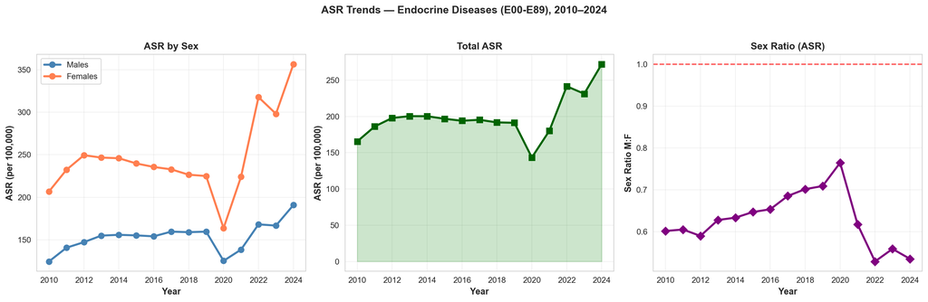

Figure 1: Trends in age-standardized rates — Endocrine diseases (E00-E89), 2010–2024

```python
fig, axes = plt.subplots(1, 3, figsize=(16, 5))

# Panel 1: By sex
ax1 = axes[0]
for sex, color, label in [('Male', 'steelblue', 'Males'), ('Female', 'coral', 'Females')]:
    sex_data = asr_by_sex[asr_by_sex['sex'] == sex]
    ax1.plot(sex_data['year'], sex_data['asr'], marker='o', linewidth=2.5,
            label=label, markersize=7, color=color)
ax1.set_xlabel('Year', fontsize=11, fontweight='bold')
ax1.set_ylabel('ASR (per 100,000)', fontsize=11, fontweight='bold')
ax1.set_title('ASR by Sex', fontsize=12, fontweight='bold')
ax1.legend(fontsize=10, loc='best')
ax1.grid(True, alpha=0.3)

# Panel 2: Total ASR
ax2 = axes[1]
ax2.plot(asr_sex_cols['year'], asr_sex_cols['asr_total'], marker='s', linewidth=2.5,
         color='darkgreen', markersize=7)
ax2.fill_between(asr_sex_cols['year'], asr_sex_cols['asr_total'], alpha=0.2, color='green')
ax2.set_xlabel('Year', fontsize=11, fontweight='bold')
ax2.set_ylabel('ASR (per 100,000)', fontsize=11, fontweight='bold')
ax2.set_title('Total ASR', fontsize=12, fontweight='bold')
ax2.grid(True, alpha=0.3)

# Panel 3: Sex ratio
asr_sex_cols['sex_ratio'] = (asr_sex_cols['asr_male'] / asr_sex_cols['asr_female'].replace(0, np.nan)).round(4)
ax3 = axes[2]
ax3.plot(asr_sex_cols['year'], asr_sex_cols['sex_ratio'], marker='D', linewidth=2.5,
         color='purple', markersize=7)
ax3.axhline(y=1, color='red', linestyle='--', linewidth=1.5, alpha=0.7)
ax3.set_xlabel('Year', fontsize=11, fontweight='bold')
ax3.set_ylabel('Sex Ratio M:F', fontsize=11, fontweight='bold')
ax3.set_title('Sex Ratio (ASR)', fontsize=12, fontweight='bold')
ax3.grid(True, alpha=0.3)

plt.suptitle('ASR Trends — Endocrine Diseases (E00-E89), 2010–2024',
             fontsize=13, fontweight='bold', y=1.03)
plt.tight_layout()
save_figure(fig, 'asr_time_series_by_sex.png')
plt.show()
```

## 3.2 Analysis by ICD Category

### 3.2.1 ASR by Disease Category

```python
latest_year_icd = asr_by_icd['year'].max()
asr_latest = asr_by_icd[asr_by_icd['year'] == latest_year_icd].copy()
asr_latest['disease_name'] = asr_latest['icd_category'].map(ICD10_MAPPING)

asr_latest[['icd_category', 'disease_name', 'hospitalizations', 'asr']].style.format({
    'hospitalizations': '{:,.0f}',
    'asr': '{:.2f}'
}).hide(axis="index")
```

| icd_category | disease_name | hospitalizations | asr |
| --- | --- | --- | --- |
| E00-E07 | Thyroid Disorders | 2,726 | 11.49 |
| E08-E13 | Diabetes Mellitus | 15,986 | 62.02 |
| E15-E16 | Other Glucose Regulation Disorders | 1,311 | 5.01 |
| E20-E35 | Disorders of Other Endocrine Glands | 1,502 | 6.53 |
| E40-E46 | Malnutrition | 444 | 2.32 |
| E50-E64 | Other Nutritional Deficiencies | 181 | 0.79 |
| E65-E68 | Obesity and Overweight | 29,900 | 140.62 |
| E70-E88 | Metabolic Disorders | 10,375 | 43.12 |
| E89 | Post-surgical Complications | 60 | 0.25 |

Table 3: Age-standardized rates by ICD category — Latest available year (per 100,000 population)

```python
icd_summary[['icd_category', 'disease_name', 'hospitalizations', 'asr']].style.format({
    'hospitalizations': '{:,.0f}',
    'asr': '{:.2f}'
}).hide(axis="index")
```

| icd_category | disease_name | hospitalizations | asr |
| --- | --- | --- | --- |
| E65-E68 | Obesity and Overweight | 198,410 | 66.84 |
| E08-E13 | Diabetes Mellitus | 173,132 | 52.47 |
| E70-E88 | Metabolic Disorders | 123,838 | 40.90 |
| E00-E07 | Thyroid Disorders | 49,813 | 16.10 |
| E15-E16 | Other Glucose Regulation Disorders | 37,641 | 11.16 |
| E20-E35 | Disorders of Other Endocrine Glands | 23,894 | 8.15 |
| E40-E46 | Malnutrition | 7,140 | 2.77 |
| E50-E64 | Other Nutritional Deficiencies | 2,121 | 0.69 |
| E89 | Post-surgical Complications | 575 | 0.18 |

Table 4: Summary of hospitalizations and mean ASR by ICD category (2010–2024)

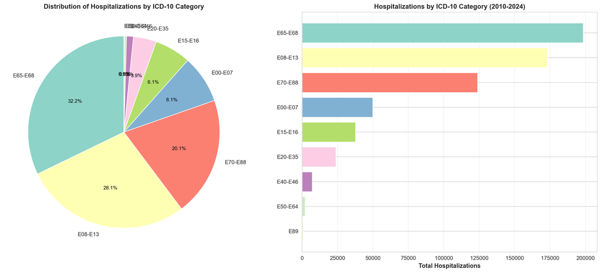

```
Figure saved: icd_distribution.png
```

```python
# Pie chart of hospitalizations by ICD category
fig, (ax1, ax2) = plt.subplots(1, 2, figsize=(16, 7))

# Pie chart
colors = plt.cm.Set3(np.linspace(0, 1, len(icd_summary)))
wedges, texts, autotexts = ax1.pie(icd_summary['hospitalizations'],
                                     labels=icd_summary['icd_category'],
                                     autopct='%1.1f%%',
                                     colors=colors,
                                     startangle=90)
ax1.set_title('Distribution of Hospitalizations by ICD-10 Category',
              fontsize=12, fontweight='bold')

for autotext in autotexts:
    autotext.set_color('black')
    autotext.set_fontsize(9)

# Bar chart
icd_sorted = icd_summary.sort_values('hospitalizations', ascending=True)
ax2.barh(icd_sorted['icd_category'], icd_sorted['hospitalizations'], color=colors[::-1])
ax2.set_xlabel('Total Hospitalizations', fontsize=11, fontweight='bold')
ax2.set_title('Hospitalizations by ICD-10 Category (2010-2024)',
              fontsize=12, fontweight='bold')
ax2.grid(axis='x', alpha=0.3)

plt.tight_layout()
save_figure(fig, 'icd_distribution.png')
plt.show()

print("Figure saved: icd_distribution.png")
```

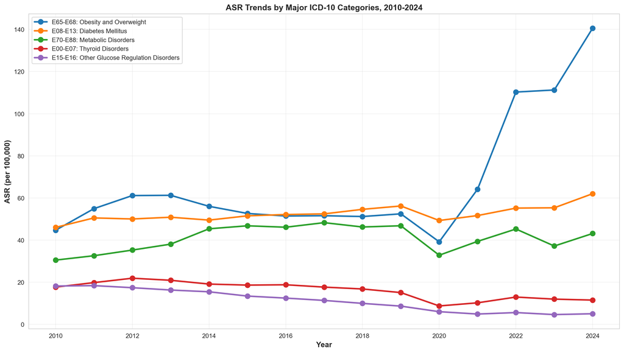

```
Figure saved: asr_trends_by_icd.png
```

```python
# ASR trends by top ICD categories
top_icd = icd_summary.head(5)['icd_category'].tolist()
asr_icd_subset = asr_by_icd[asr_by_icd['icd_category'].isin(top_icd)]

fig, ax = plt.subplots(figsize=(14, 8))

for icd in top_icd:
    icd_data = asr_icd_subset[asr_icd_subset['icd_category'] == icd]
    disease_name = ICD10_MAPPING.get(icd, icd)
    ax.plot(icd_data['year'], icd_data['asr'], marker='o', linewidth=2.5,
            label=f"{icd}: {disease_name}", markersize=8)

ax.set_xlabel('Year', fontsize=12, fontweight='bold')
ax.set_ylabel('ASR (per 100,000)', fontsize=12, fontweight='bold')
ax.set_title('ASR Trends by Major ICD-10 Categories, 2010-2024',
             fontsize=13, fontweight='bold')
ax.legend(fontsize=10, loc='best')
ax.grid(True, alpha=0.3)
plt.tight_layout()
save_figure(fig, 'asr_trends_by_icd.png')
plt.show()

print("Figure saved: asr_trends_by_icd.png")
```

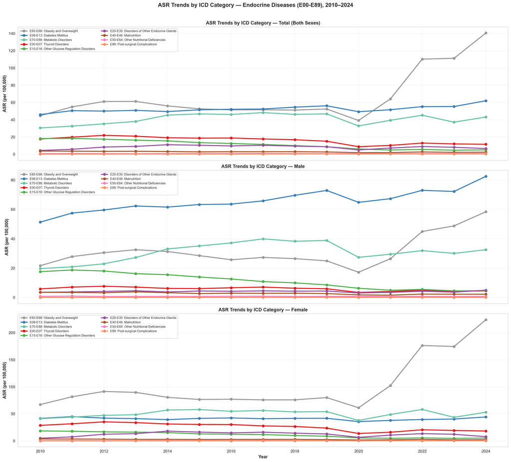

Figure 2: ASR Trends by All ICD Categories — Total, Male, and Female (2010–2024)

```python
# Compute ASR by ICD category for each sex separately
who_weights_df = pd.DataFrame([
    {'age_group': k, 'who_weight': v} for k, v in WHO_STANDARD_POPULATION.items()
])

def _asr_by_icd_sex(hosp_df, pop_df, sex_filter=None, per=100000):
    if sex_filter:
        h = hosp_df[hosp_df['sex'] == sex_filter].groupby(
            ['year', 'age_group', 'icd_category'])['hospitalizations'].sum().reset_index()
        p = pop_df[pop_df['sex'] == sex_filter].groupby(
            ['year', 'age_group'])['population'].sum().reset_index()
    else:
        h = hosp_df.groupby(
            ['year', 'age_group', 'icd_category'])['hospitalizations'].sum().reset_index()
        p = pop_df.groupby(
            ['year', 'age_group'])['population'].sum().reset_index()
    m = h.merge(p, on=['year', 'age_group'], how='left').dropna(subset=['population'])
    m = m[m['population'] > 0]
    m['rate'] = (m['hospitalizations'] / m['population']) * per
    m = m.merge(who_weights_df, on='age_group', how='left')
    m['wr'] = m['rate'] * m['who_weight']
    agg = m.groupby(['year', 'icd_category']).agg(
        hospitalizations=('hospitalizations', 'sum'), weighted_rate=('wr', 'sum')
    ).reset_index()
    agg['asr'] = (agg['weighted_rate'] / TOTAL_WHO_WEIGHT).round(2)
    return agg[['year', 'icd_category', 'hospitalizations', 'asr']]

asr_icd_total  = _asr_by_icd_sex(hosp_by_icd, population, sex_filter=None)
asr_icd_male   = _asr_by_icd_sex(hosp_by_icd, population, sex_filter='Male')
asr_icd_female = _asr_by_icd_sex(hosp_by_icd, population, sex_filter='Female')

icd_list = icd_summary['icd_category'].tolist()

fig, axes = plt.subplots(3, 1, figsize=(18, 16), sharex=True)
panel_data = [
    (axes[0], asr_icd_total, 'Total (Both Sexes)'),
    (axes[1], asr_icd_male, 'Male'),
    (axes[2], asr_icd_female, 'Female'),
]

for ax, data, title in panel_data:
    for icd_cat in icd_list:
        icd_data = data[data['icd_category'] == icd_cat]
        ax.plot(icd_data['year'], icd_data['asr'], marker='o', linewidth=2.5,
                label=f"{icd_cat}: {ICD10_MAPPING.get(icd_cat, icd_cat)}", markersize=6,
                color=ICD_COLORS.get(icd_cat, None))
    ax.set_ylabel('ASR (per 100,000)', fontsize=11, fontweight='bold')
    ax.set_title(f'ASR Trends by ICD Category — {title}', fontsize=12, fontweight='bold')
    ax.legend(fontsize=8, loc='best', ncol=2)
    ax.grid(True, alpha=0.3)

axes[2].set_xlabel('Year', fontsize=11, fontweight='bold')
plt.suptitle('ASR Trends by ICD Category — Endocrine Diseases (E00-E89), 2010–2024',
             fontsize=14, fontweight='bold', y=1.01)
plt.tight_layout()
save_figure(fig, 'asr_trends_all_icd_endocrinas.png')
plt.show()
```

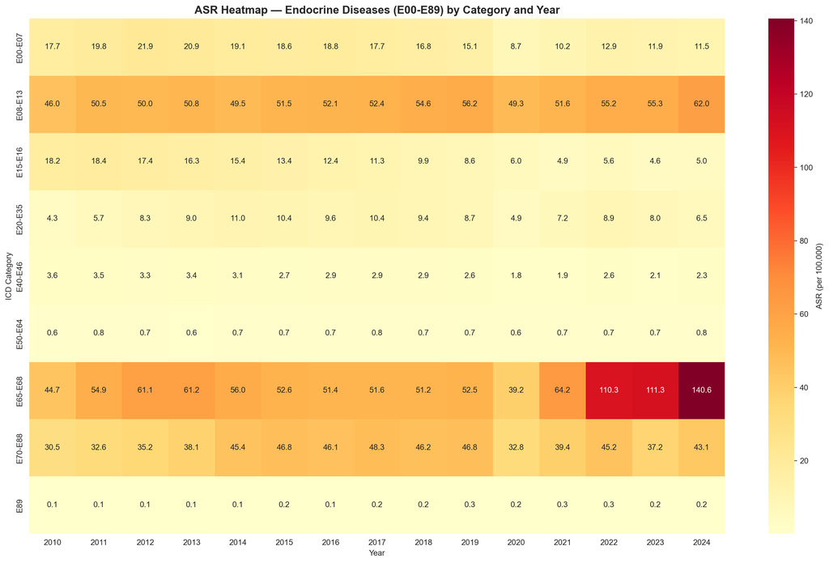

Figure 3: ASR Heatmap by ICD Category and Year

```python
heatmap_data = asr_by_icd.pivot_table(index='icd_category', columns='year', values='asr', aggfunc='first')

fig, ax = plt.subplots(figsize=(16, 10))
sns.heatmap(heatmap_data, annot=True, fmt='.1f', cmap='YlOrRd',
            cbar_kws={'label': 'ASR (per 100,000)'}, ax=ax)
ax.set_title('ASR Heatmap — Endocrine Diseases (E00-E89) by Category and Year', fontweight='bold', fontsize=14)
ax.set_xlabel('Year')
ax.set_ylabel('ICD Category')
plt.tight_layout()
save_figure(fig, 'asr_heatmap_icd_endocrinas.png')
plt.show()
```

## 3.3 Regional Analysis

```python
# Use hosp_regional already computed in redistribute-age-groups block
# Count by region and year
regional_count = hosp_regional.groupby(['year', 'region'])['hospitalizations'].sum().reset_index()

# Merge with population (sum across all ages for regional totals)
regional_pop = pop_data.groupby(['year', 'region']).agg({'population': 'sum'}).reset_index()

regional_merged = regional_count.merge(regional_pop, on=['year', 'region'], how='left')
regional_merged = regional_merged.dropna(subset=['population'])
regional_merged = regional_merged[regional_merged['population'] > 0]

# Calculate crude rates for regions (simplified, not age-standardized for this view)
regional_merged['crude_rate'] = ((regional_merged['hospitalizations'] / regional_merged['population']) * 100000).round(2)

# Display regional summary
regional_summary = regional_merged.groupby('region').agg({
    'hospitalizations': 'sum',
    'population': 'mean',
    'crude_rate': 'mean'
}).reset_index()
regional_summary['crude_rate'] = regional_summary['crude_rate'].round(2)
regional_summary = regional_summary.sort_values('crude_rate', ascending=False)
```

```python
reg_display = regional_summary.copy()
reg_display.columns = ['Region', 'Hospitalizations', 'Mean Population', 'Mean Crude Rate']

reg_display.style.format({
    'Hospitalizations': '{:,.0f}',
    'Mean Population': '{:,.0f}',
    'Mean Crude Rate': '{:.2f}'
}).hide(axis="index")
```

| Region | Hospitalizations | Mean Population | Mean Crude Rate |
| --- | --- | --- | --- |
| Aysén | 4,723 | 105,106 | 298.08 |
| Magallanes | 6,768 | 172,147 | 263.30 |
| Metropolitana | 273,645 | 7,635,385 | 238.17 |
| Los Lagos | 31,229 | 868,713 | 237.74 |
| Los Ríos | 14,162 | 398,354 | 236.78 |
| Biobío | 55,963 | 1,632,796 | 227.55 |
| Ñuble | 16,578 | 500,469 | 220.02 |
| La Araucanía | 31,795 | 993,796 | 212.65 |
| Antofagasta | 20,396 | 639,145 | 210.99 |
| Valparaíso | 59,719 | 1,889,531 | 210.82 |
| Tarapacá | 10,711 | 349,855 | 202.83 |
| O'Higgins | 28,847 | 955,292 | 200.48 |
| Maule | 32,485 | 1,093,589 | 196.10 |
| Atacama | 8,952 | 304,917 | 194.31 |
| Arica y Parinacota | 4,908 | 239,120 | 134.33 |
| Coquimbo | 15,133 | 794,452 | 125.24 |

Table 5: Summary of hospitalizations by region — Endocrine diseases (2010–2024)

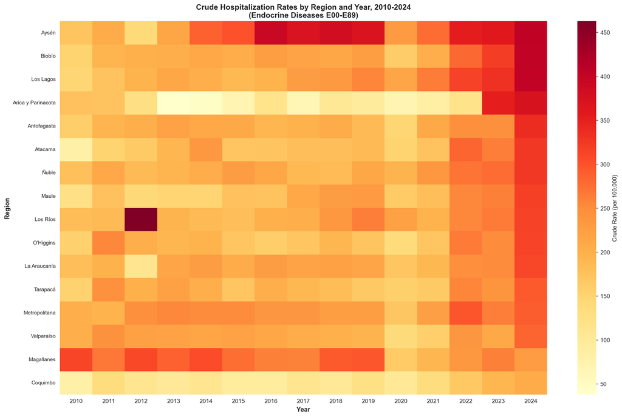

```
Figure saved: regional_heatmap.png
```

```python
# Heatmap of crude rates by region and year
regional_pivot = regional_merged.pivot_table(
    values='crude_rate',
    index='region',
    columns='year',
    aggfunc='first'
)

# Sort by 2024 rate
regional_pivot = regional_pivot.loc[regional_pivot[2024].sort_values(ascending=False).index]

fig, ax = plt.subplots(figsize=(16, 10))
sns.heatmap(regional_pivot, annot=False, fmt='.0f', cmap='YlOrRd', ax=ax, cbar_kws={'label': 'Crude Rate (per 100,000)'})
ax.set_title('Crude Hospitalization Rates by Region and Year, 2010-2024\n(Endocrine Diseases E00-E89)',
             fontsize=13, fontweight='bold')
ax.set_xlabel('Year', fontsize=11, fontweight='bold')
ax.set_ylabel('Region', fontsize=11, fontweight='bold')
plt.xticks(rotation=0)
plt.yticks(rotation=0, fontsize=9)
plt.tight_layout()
save_figure(fig, 'regional_heatmap.png')
plt.show()

print("Figure saved: regional_heatmap.png")
```

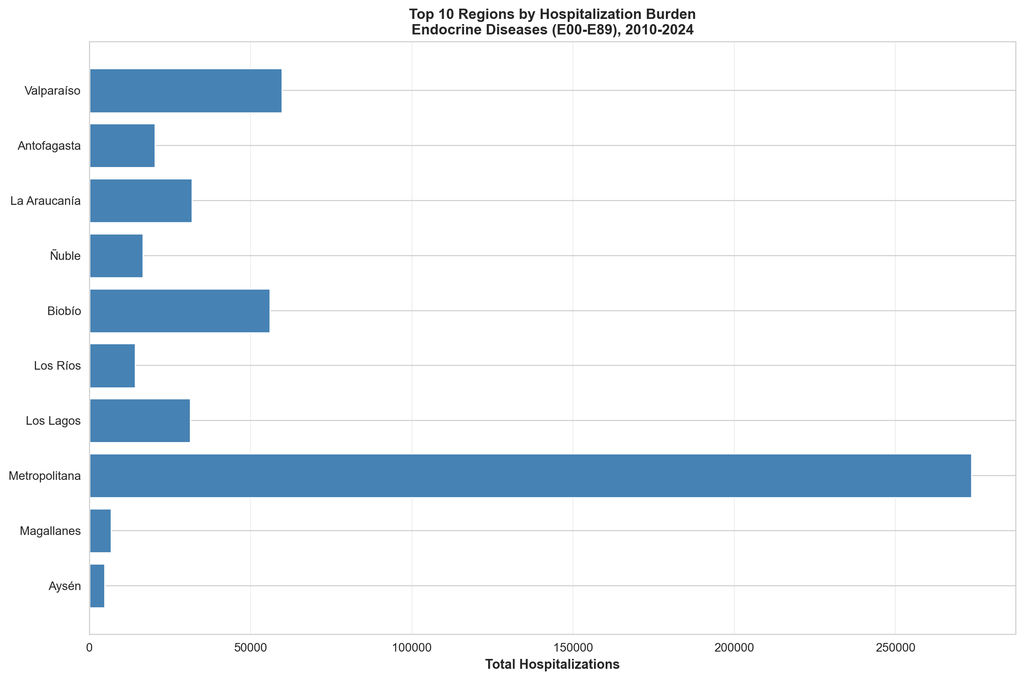

```
Figure saved: top_regions_hospitalization.png
```

```python
# Top 10 regions by hospitalization burden
top_regions = regional_summary.head(10)

fig, ax = plt.subplots(figsize=(12, 8))
ax.barh(top_regions['region'], top_regions['hospitalizations'], color='steelblue')
ax.set_xlabel('Total Hospitalizations', fontsize=11, fontweight='bold')
ax.set_title('Top 10 Regions by Hospitalization Burden\nEndocrine Diseases (E00-E89), 2010-2024',
             fontsize=12, fontweight='bold')
ax.grid(axis='x', alpha=0.3)
plt.tight_layout()
save_figure(fig, 'top_regions_hospitalization.png')
plt.show()

print("Figure saved: top_regions_hospitalization.png")
```

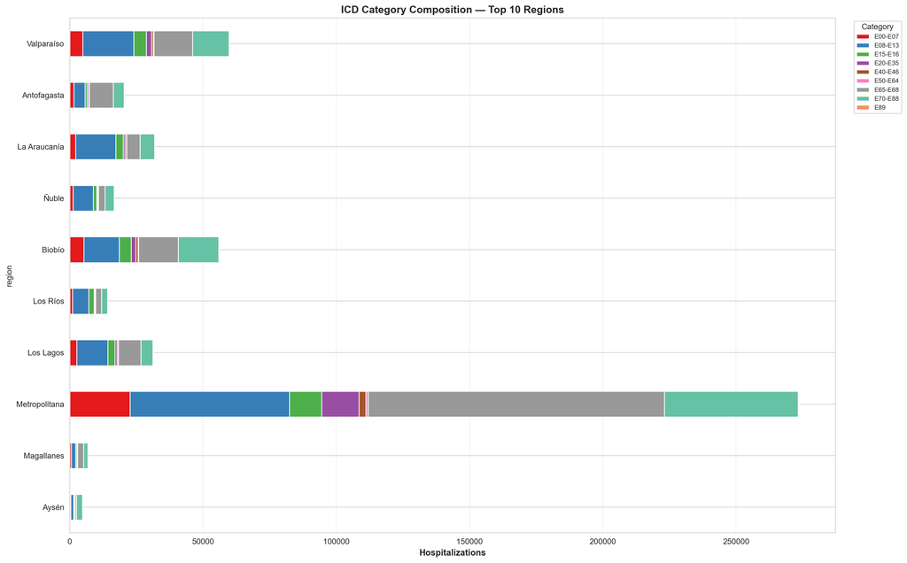

Figure 4: ICD Category Composition — Top 10 Regions

```python
top10_regions = regional_summary.head(10)['region'].tolist()
reg_icd_data = egresos_df[egresos_df['region'].isin(top10_regions)].groupby(
    ['region', 'icd_category']).size().reset_index(name='count')
reg_icd_pivot = reg_icd_data.pivot_table(index='region', columns='icd_category', values='count', fill_value=0)
reg_icd_pivot = reg_icd_pivot.loc[top10_regions]

fig, ax = plt.subplots(figsize=(16, 10))
reg_icd_pivot.plot(kind='barh', stacked=True, ax=ax,
                    color=[ICD_COLORS.get(c, '#ccc') for c in reg_icd_pivot.columns])
ax.set_xlabel('Hospitalizations', fontsize=11, fontweight='bold')
ax.set_title('ICD Category Composition — Top 10 Regions', fontsize=13, fontweight='bold')
ax.legend(title='Category', bbox_to_anchor=(1.02, 1), loc='upper left', fontsize=8)
ax.grid(axis='x', alpha=0.3)
plt.tight_layout()
save_figure(fig, 'regional_icd_composition_endocrinas.png')
plt.show()
```

## 3.4 Sex Ratio Analysis

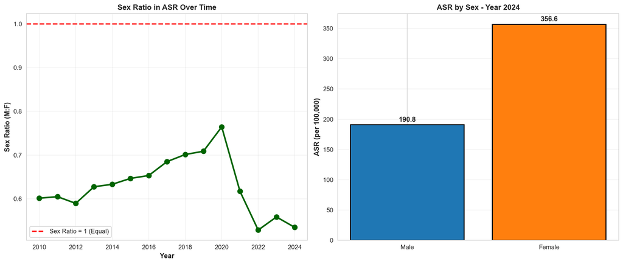

Figure 5: Sex ratio analysis — Endocrine diseases (E00-E89)

```
Figure saved: sex_ratio_analysis.png
```

```python
# Sex ratio already computed in section 4; reuse
sex_ratio_data = asr_sex_cols[asr_sex_cols['sex_ratio'].notna()].copy()

fig, (ax1, ax2) = plt.subplots(1, 2, figsize=(14, 6))

# Time series of sex ratio
ax1.plot(sex_ratio_data['year'], sex_ratio_data['sex_ratio'], marker='o', linewidth=2.5,
         color='darkgreen', markersize=8)
ax1.axhline(y=1, color='red', linestyle='--', linewidth=2, label='Sex Ratio = 1 (Equal)')
ax1.set_xlabel('Year', fontsize=11, fontweight='bold')
ax1.set_ylabel('Sex Ratio (M:F)', fontsize=11, fontweight='bold')
ax1.set_title('Sex Ratio in ASR Over Time', fontsize=12, fontweight='bold')
ax1.legend(fontsize=10)
ax1.grid(True, alpha=0.3)

# Absolute ASR by sex (latest year)
latest_year = asr_sex_cols['year'].max()
latest_data = asr_sex_cols[asr_sex_cols['year'] == latest_year].iloc[0]

sexes = ['Male', 'Female']
asr_values = [latest_data['asr_male'], latest_data['asr_female']]
colors_bar = ['#1f77b4', '#ff7f0e']

ax2.bar(sexes, asr_values, color=colors_bar, edgecolor='black', linewidth=1.5)
ax2.set_ylabel('ASR (per 100,000)', fontsize=11, fontweight='bold')
ax2.set_title(f'ASR by Sex - Year {latest_year}', fontsize=12, fontweight='bold')
ax2.grid(axis='y', alpha=0.3)

for i, (sex, val) in enumerate(zip(sexes, asr_values)):
    ax2.text(i, val + 5, f'{val:.1f}', ha='center', fontsize=11, fontweight='bold')

plt.tight_layout()
save_figure(fig, 'sex_ratio_analysis.png')
plt.show()

print("Figure saved: sex_ratio_analysis.png")
```

```python
sr_display = asr_sex_cols[['year', 'hosp_male', 'hosp_female', 'asr_male', 'asr_female', 'sex_ratio']].copy()
sr_display.columns = ['Year', 'Hosp. Males', 'Hosp. Females', 'ASR Males', 'ASR Females', 'Ratio M:F (ASR)']

sr_display.style.format({
    'Hosp. Males': '{:,.0f}',
    'Hosp. Females': '{:,.0f}',
    'ASR Males': '{:.2f}',
    'ASR Females': '{:.2f}',
    'Ratio M:F (ASR)': '{:.2f}'
}).hide(axis="index")
```

| Year | Hosp. Males | Hosp. Females | ASR Males | ASR Females | Ratio M:F (ASR) |
| --- | --- | --- | --- | --- | --- |
| 2010 | 10,544 | 19,498 | 124.38 | 206.76 | 0.60 |
| 2011 | 12,225 | 22,221 | 140.54 | 232.29 | 0.60 |
| 2012 | 13,093 | 24,127 | 147.10 | 249.46 | 0.59 |
| 2013 | 14,031 | 24,234 | 154.84 | 246.68 | 0.63 |
| 2014 | 14,351 | 24,451 | 155.73 | 245.91 | 0.63 |
| 2015 | 14,544 | 24,067 | 155.07 | 239.75 | 0.65 |
| 2016 | 14,742 | 23,898 | 153.96 | 235.64 | 0.65 |
| 2017 | 15,516 | 23,913 | 159.51 | 232.84 | 0.69 |
| 2018 | 15,951 | 23,907 | 158.87 | 226.49 | 0.70 |
| 2019 | 16,492 | 24,436 | 159.49 | 224.99 | 0.71 |
| 2020 | 13,433 | 18,265 | 125.11 | 163.65 | 0.76 |
| 2021 | 15,020 | 24,737 | 138.37 | 224.11 | 0.62 |
| 2022 | 18,603 | 35,277 | 168.04 | 317.84 | 0.53 |
| 2023 | 18,832 | 33,671 | 166.62 | 298.23 | 0.56 |
| 2024 | 22,027 | 40,458 | 190.78 | 356.65 | 0.53 |

Table 6: Male-to-female ratio by year — Endocrine diseases

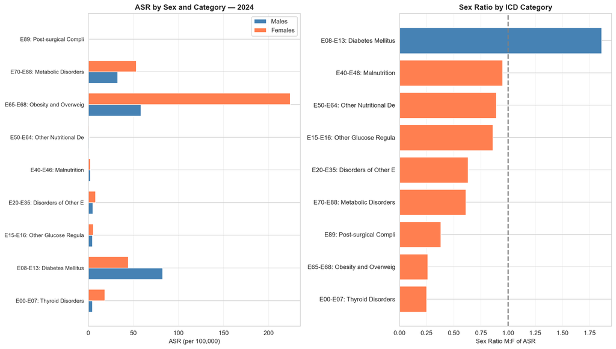

Figure 6: M:F Sex Ratio of ASR by ICD Category — Endocrine Diseases (Latest Year)

```python
# Compute sex-specific ASR by ICD category for the latest year
hosp_sex_icd = hosp_5year.groupby(['year', 'age_group', 'sex', 'icd_category']).agg(
    {'hospitalizations': 'sum'}).reset_index()
who_weights = pd.DataFrame([{'age_group': k, 'who_weight': v} for k, v in WHO_STANDARD_POPULATION.items()])

icd_sex_list = []
for icd_cat in icd_summary['icd_category'].tolist():
    for sex in ['Male', 'Female']:
        icd_sex_data = hosp_sex_icd[
            (hosp_sex_icd['year'] == latest_year) &
            (hosp_sex_icd['icd_category'] == icd_cat) &
            (hosp_sex_icd['sex'] == sex)
        ]
        sex_pop = pop_data[(pop_data['year'] == latest_year) & (pop_data['sex'] == sex)]
        sex_pop_agg = sex_pop.groupby('age_group')['population'].sum().reset_index()
        merged = icd_sex_data.merge(sex_pop_agg, on='age_group', how='left')
        merged = merged[merged['population'] > 0].dropna(subset=['population'])
        merged['age_specific_rate'] = (merged['hospitalizations'] / merged['population']) * 100000
        merged = merged.merge(who_weights, on='age_group', how='left')
        merged['weighted_rate'] = merged['age_specific_rate'] * merged['who_weight']
        asr_val = merged['weighted_rate'].sum() / TOTAL_WHO_WEIGHT
        icd_sex_list.append({'icd_category': icd_cat, 'sex': sex, 'asr': round(asr_val, 2)})

icd_sex_df = pd.DataFrame(icd_sex_list)
icd_sex_pivot = icd_sex_df.pivot(index='icd_category', columns='sex', values='asr').fillna(0)
icd_sex_pivot['ratio'] = (icd_sex_pivot['Male'] / icd_sex_pivot['Female'].replace(0, np.nan)).round(2)

fig, axes = plt.subplots(1, 2, figsize=(14, 8))

ax1 = axes[0]
x = np.arange(len(icd_sex_pivot))
width = 0.35
ax1.barh(x - width/2, icd_sex_pivot['Male'], width, label='Males', color='steelblue')
ax1.barh(x + width/2, icd_sex_pivot['Female'], width, label='Females', color='coral')
ax1.set_yticks(x)
ax1.set_yticklabels([f'{s}: {ICD10_MAPPING.get(s, s)[:20]}' for s in icd_sex_pivot.index], fontsize=9)
ax1.set_xlabel('ASR (per 100,000)')
ax1.set_title(f'ASR by Sex and Category — {int(latest_year)}', fontweight='bold')
ax1.legend()
ax1.grid(axis='x', alpha=0.3)

ax2 = axes[1]
ratio_sorted = icd_sex_pivot.sort_values('ratio', ascending=True)
colors_ratio = ['coral' if r < 1 else 'steelblue' for r in ratio_sorted['ratio']]
ax2.barh([f'{s}: {ICD10_MAPPING.get(s, s)[:20]}' for s in ratio_sorted.index],
         ratio_sorted['ratio'], color=colors_ratio)
ax2.axvline(x=1, color='gray', linestyle='--', linewidth=2)
ax2.set_xlabel('Sex Ratio M:F of ASR')
ax2.set_title('Sex Ratio by ICD Category', fontweight='bold')
ax2.grid(axis='x', alpha=0.3)

plt.tight_layout()
save_figure(fig, 'sex_ratio_by_icd_endocrinas.png')
plt.show()
```

## 3.5 Age Distribution

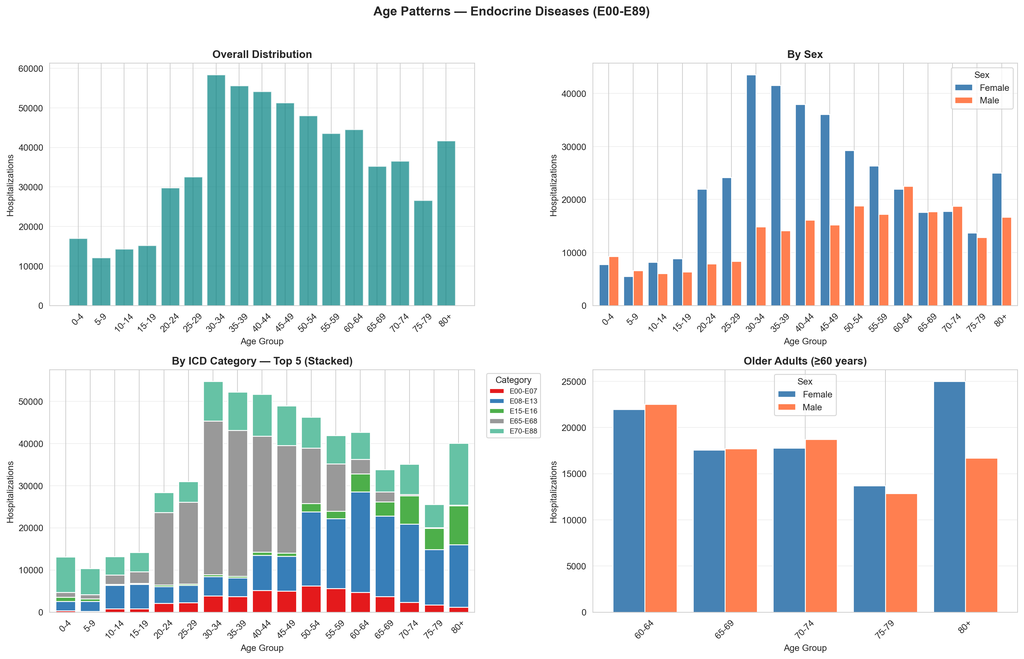

Figure 7: Age distribution of hospitalizations for endocrine diseases

```python
# AGE_ORDER already defined in constants block

age_hosp = hosp_overall.groupby('age_group')['hospitalizations'].sum()
age_hosp = age_hosp.reindex([a for a in AGE_ORDER if a in age_hosp.index])

age_sex = hosp_overall.groupby(['age_group', 'sex'])['hospitalizations'].sum().unstack(fill_value=0)
age_sex = age_sex.reindex([a for a in AGE_ORDER if a in age_sex.index])

fig, axes = plt.subplots(2, 2, figsize=(16, 10))

# Overall age distribution
ax1 = axes[0, 0]
ax1.bar(age_hosp.index, age_hosp.values, color='teal', alpha=0.7)
ax1.set_xlabel('Age Group')
ax1.set_ylabel('Hospitalizations')
ax1.set_title('Overall Distribution', fontweight='bold')
ax1.tick_params(axis='x', rotation=45)
ax1.grid(True, alpha=0.3, axis='y')

# By sex
ax2 = axes[0, 1]
age_sex.plot(kind='bar', ax=ax2, color=['steelblue', 'coral'], width=0.8)
ax2.set_xlabel('Age Group')
ax2.set_ylabel('Hospitalizations')
ax2.set_title('By Sex', fontweight='bold')
ax2.tick_params(axis='x', rotation=45)
ax2.legend(title='Sex')
ax2.grid(True, alpha=0.3, axis='y')

# By ICD category and age (top 5)
ax3 = axes[1, 0]
top5_icd = icd_summary.head(5)['icd_category'].tolist()
hosp_by_icd_cat = hosp_5year.groupby(['age_group', 'icd_category'])['hospitalizations'].sum().reset_index()
age_icd = hosp_by_icd_cat[hosp_by_icd_cat['icd_category'].isin(top5_icd)].pivot_table(
    index='age_group', columns='icd_category', values='hospitalizations', fill_value=0)
age_icd = age_icd.reindex([a for a in AGE_ORDER if a in age_icd.index])
age_icd.plot(kind='bar', ax=ax3, width=0.8, stacked=True,
              color=[ICD_COLORS.get(s, '#ccc') for s in age_icd.columns])
ax3.set_xlabel('Age Group')
ax3.set_ylabel('Hospitalizations')
ax3.set_title('By ICD Category — Top 5 (Stacked)', fontweight='bold')
ax3.tick_params(axis='x', rotation=45)
ax3.legend(title='Category', bbox_to_anchor=(1.02, 1), loc='upper left', fontsize=8)
ax3.grid(True, alpha=0.3, axis='y')

# Elderly focus (60+)
ax4 = axes[1, 1]
elderly_groups = ['60-64', '65-69', '70-74', '75-79', '80+']
elderly = hosp_overall[hosp_overall['age_group'].isin(elderly_groups)]
eld_by_sex = elderly.groupby(['age_group', 'sex'])['hospitalizations'].sum().unstack(fill_value=0)
eld_by_sex = eld_by_sex.reindex([a for a in elderly_groups if a in eld_by_sex.index])
eld_by_sex.plot(kind='bar', ax=ax4, color=['steelblue', 'coral'], width=0.8)
ax4.set_xlabel('Age Group')
ax4.set_ylabel('Hospitalizations')
ax4.set_title('Older Adults (≥60 years)', fontweight='bold')
ax4.tick_params(axis='x', rotation=45)
ax4.legend(title='Sex')
ax4.grid(True, alpha=0.3, axis='y')

plt.suptitle('Age Patterns — Endocrine Diseases (E00-E89)', fontsize=14, fontweight='bold', y=1.02)
plt.tight_layout()
save_figure(fig, 'age_distribution_endocrinas.png')
plt.show()
```

```python
age_summary = hosp_overall.groupby('age_group')['hospitalizations'].sum().reset_index()
total_h = age_summary['hospitalizations'].sum()
age_summary['percentage'] = (age_summary['hospitalizations'] / total_h * 100).round(2)
age_summary['age_order'] = age_summary['age_group'].apply(lambda x: AGE_ORDER.index(x) if x in AGE_ORDER else 99)
age_summary = age_summary.sort_values('age_order').drop(columns='age_order')
age_summary.columns = ['Age Group', 'Hospitalizations', 'Percentage (%)']

age_summary.style.format({
    'Hospitalizations': '{:,.0f}',
    'Percentage (%)': '{:.2f}'
}).hide(axis="index")
```

| Age Group | Hospitalizations | Percentage (%) |
| --- | --- | --- |
| 0-4 | 17,018 | 2.76 |
| 5-9 | 12,099 | 1.96 |
| 10-14 | 14,270 | 2.31 |
| 15-19 | 15,180 | 2.46 |
| 20-24 | 29,817 | 4.84 |
| 25-29 | 32,550 | 5.28 |
| 30-34 | 58,396 | 9.47 |
| 35-39 | 55,645 | 9.03 |
| 40-44 | 54,113 | 8.78 |
| 45-49 | 51,299 | 8.32 |
| 50-54 | 48,049 | 7.79 |
| 55-59 | 43,550 | 7.06 |
| 60-64 | 44,489 | 7.22 |
| 65-69 | 35,277 | 5.72 |
| 70-74 | 36,533 | 5.93 |
| 75-79 | 26,571 | 4.31 |
| 80+ | 41,708 | 6.76 |

Table 7: Summary of hospitalizations by age group — Endocrine diseases

## 3.6 Detailed Analysis by Individual Diagnostic Category

### 3.6.1 E00-E07: Thyroid Disorders

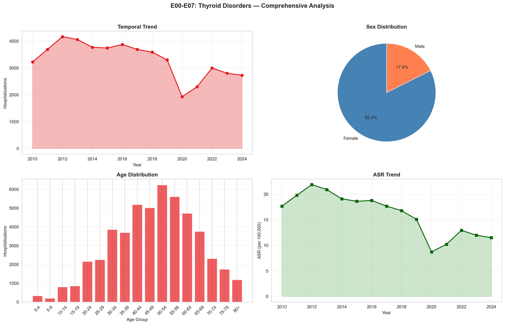

Figure 8: Detailed Analysis — Thyroid Disorders (E00-E07)

```python
fig = plot_icd_detail('E00-E07', ICD_COLORS['E00-E07'])
if fig is not None:
    save_figure(fig, 'detail_E00-E07.png')
    plt.show()
```

### 3.6.2 E08-E13: Diabetes Mellitus

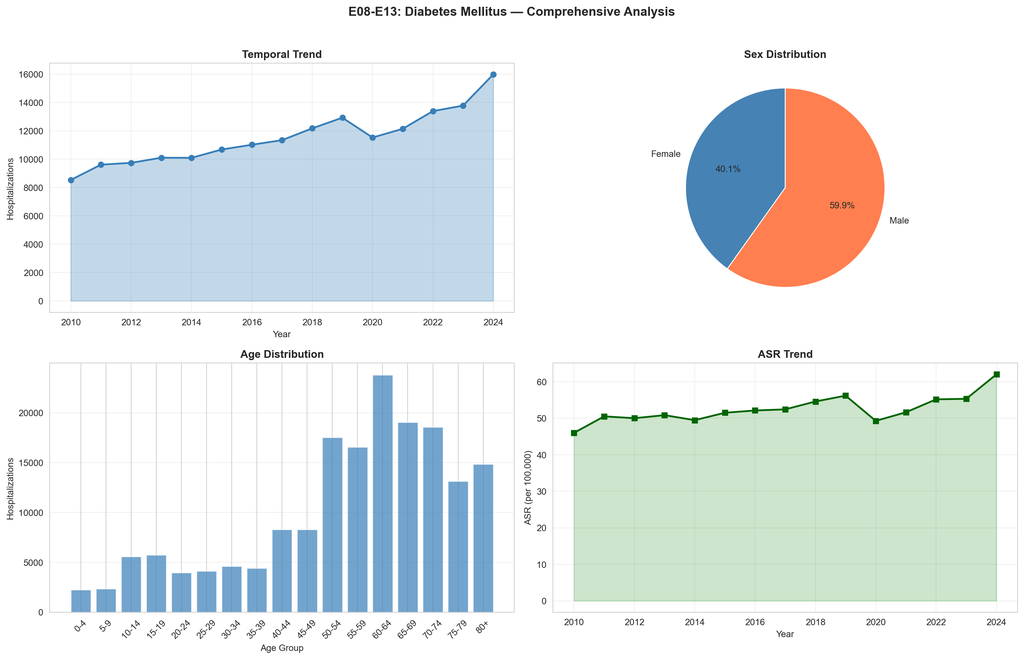

Figure 9: Detailed Analysis — Diabetes Mellitus (E08-E13)

```python
fig = plot_icd_detail('E08-E13', ICD_COLORS['E08-E13'])
if fig is not None:
    save_figure(fig, 'detail_E08-E13.png')
    plt.show()
```

### 3.6.3 E15-E16: Other Glucose Regulation Disorders

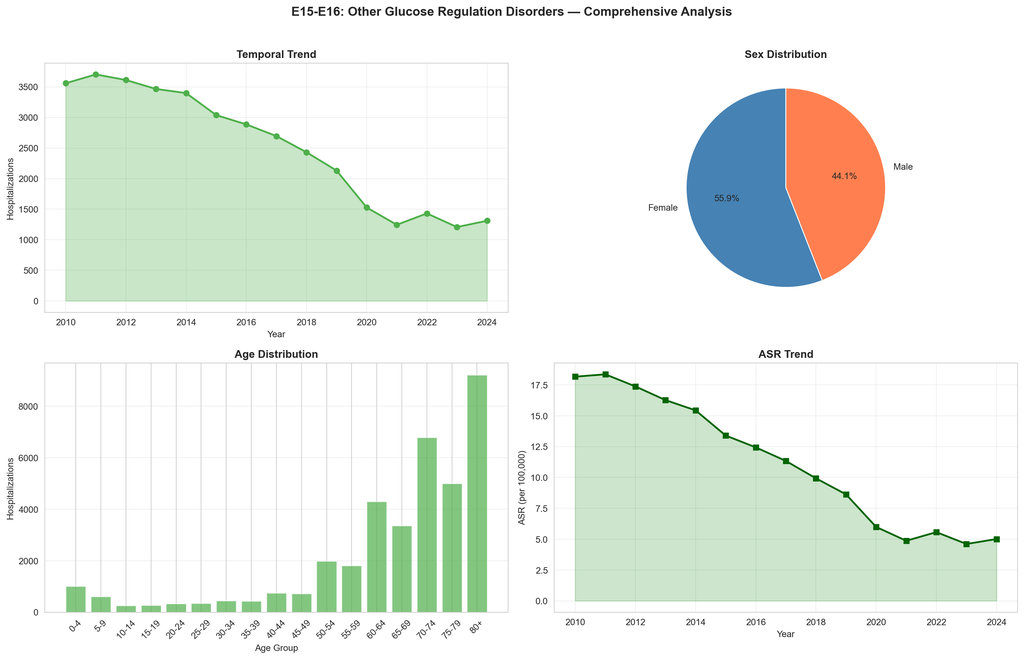

Figure 10: Detailed Analysis — Other Glucose Regulation Disorders (E15-E16)

```python
fig = plot_icd_detail('E15-E16', ICD_COLORS['E15-E16'])
if fig is not None:
    save_figure(fig, 'detail_E15-E16.png')
    plt.show()
```

### 3.6.4 E20-E35: Disorders of Other Endocrine Glands

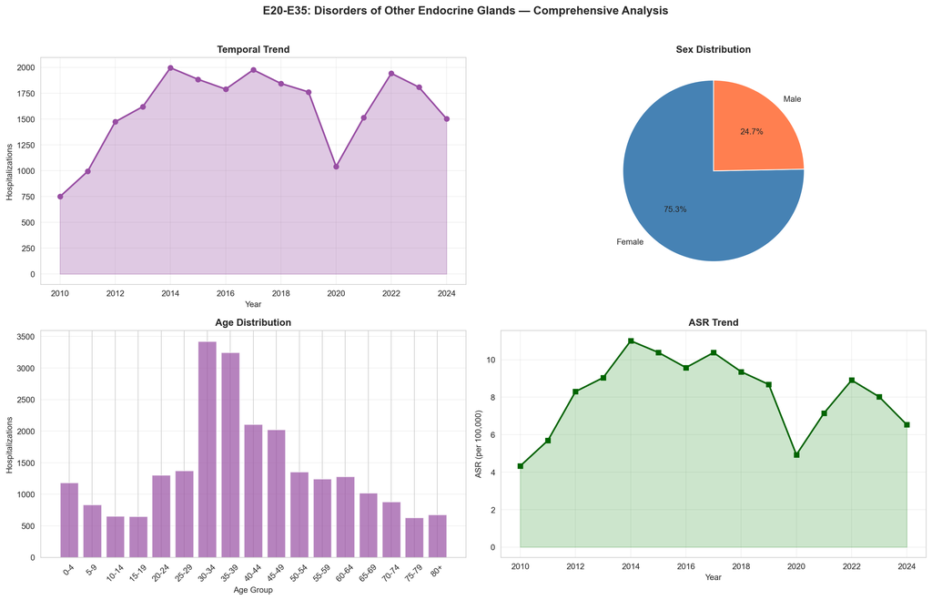

Figure 11: Detailed Analysis — Disorders of Other Endocrine Glands (E20-E35)

```python
fig = plot_icd_detail('E20-E35', ICD_COLORS['E20-E35'])
if fig is not None:
    save_figure(fig, 'detail_E20-E35.png')
    plt.show()
```

### 3.6.5 E36: Intraoperative Complications

```python
fig = plot_icd_detail('E36', ICD_COLORS['E36'])
if fig is not None:
    save_figure(fig, 'detail_E36.png')
    plt.show()
```

### 3.6.6 E40-E46: Malnutrition

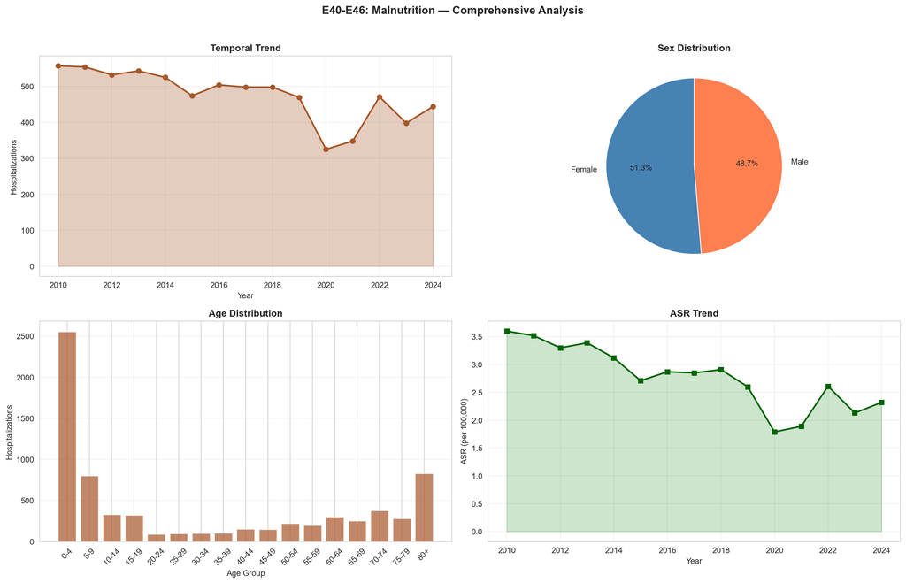

Figure 13: Detailed Analysis — Malnutrition (E40-E46)

```python
fig = plot_icd_detail('E40-E46', ICD_COLORS['E40-E46'])
if fig is not None:
    save_figure(fig, 'detail_E40-E46.png')
    plt.show()
```

### 3.6.7 E50-E64: Other Nutritional Deficiencies

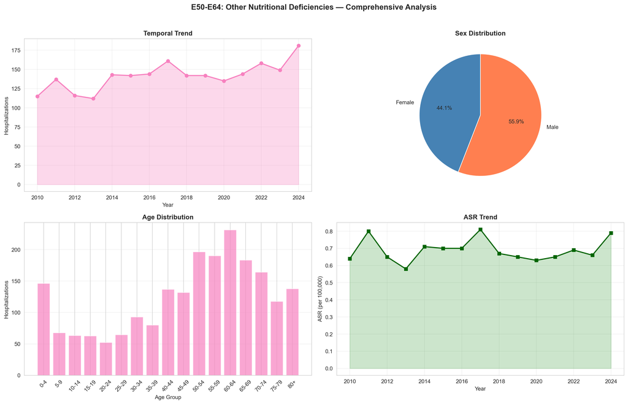

Figure 14: Detailed Analysis — Other Nutritional Deficiencies (E50-E64)

```python
fig = plot_icd_detail('E50-E64', ICD_COLORS['E50-E64'])
if fig is not None:
    save_figure(fig, 'detail_E50-E64.png')
    plt.show()
```

### 3.6.8 E65-E68: Obesity and Overweight

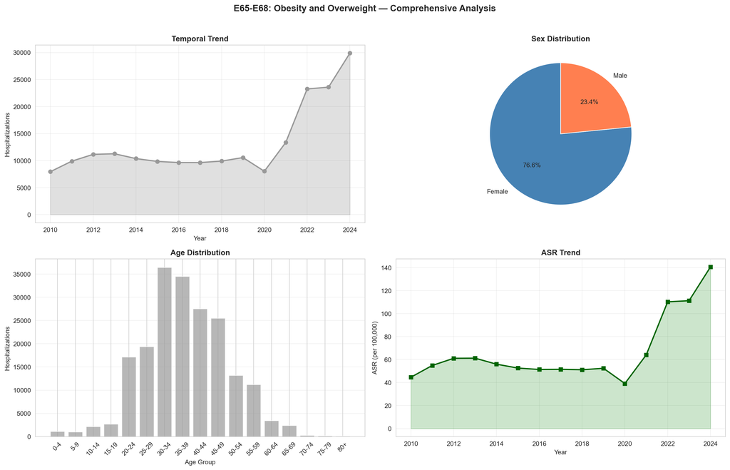

Figure 15: Detailed Analysis — Obesity and Overweight (E65-E68)

```python
fig = plot_icd_detail('E65-E68', ICD_COLORS['E65-E68'])
if fig is not None:
    save_figure(fig, 'detail_E65-E68.png')
    plt.show()
```

### 3.6.9 E70-E88: Metabolic Disorders

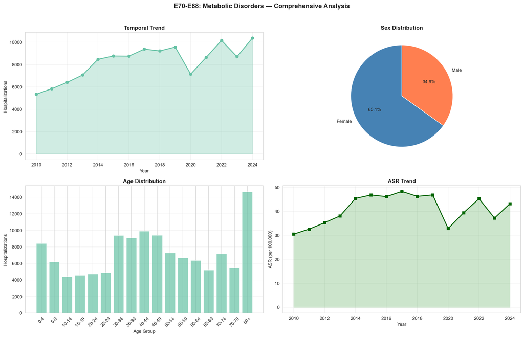

Figure 16: Detailed Analysis — Metabolic Disorders (E70-E88)

```python
fig = plot_icd_detail('E70-E88', ICD_COLORS['E70-E88'])
if fig is not None:
    save_figure(fig, 'detail_E70-E88.png')
    plt.show()
```

### 3.6.10 E89: Post-surgical Complications

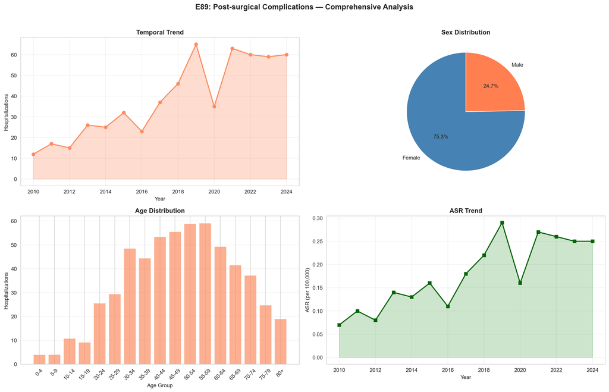

Figure 17: Detailed Analysis — Post-surgical Complications (E89)

```python
fig = plot_icd_detail('E89', ICD_COLORS['E89'])
if fig is not None:
    save_figure(fig, 'detail_E89.png')
    plt.show()
```